# Red Wine Exploration by Ryan Reardon

# Analysis

This report explores a dataset of Portuguese “Vinho Verde” red wine. We’re going to explore the relationship between the quality rating of the wine and the attributes that make up that rating of a scale between (0 = Very Bad and 10 = Very Excellent).

# Dataframe Stucture and Summary

```
## 'data.frame':    1599 obs. of  13 variables:
##  $ X                   : int  1 2 3 4 5 6 7 8 9 10 ...
##  $ fixed.acidity       : num  7.4 7.8 7.8 11.2 7.4 7.4 7.9 7.3 7.8 7.5 ...
##  $ volatile.acidity    : num  0.7 0.88 0.76 0.28 0.7 0.66 0.6 0.65 0.58 0.5 ...
##  $ citric.acid         : num  0 0 0.04 0.56 0 0 0.06 0 0.02 0.36 ...
##  $ residual.sugar      : num  1.9 2.6 2.3 1.9 1.9 1.8 1.6 1.2 2 6.1 ...
##  $ chlorides           : num  0.076 0.098 0.092 0.075 0.076 0.075 0.069 0.065 0.073 0.071 ...
##  $ free.sulfur.dioxide : num  11 25 15 17 11 13 15 15 9 17 ...
##  $ total.sulfur.dioxide: num  34 67 54 60 34 40 59 21 18 102 ...
##  $ density             : num  0.998 0.997 0.997 0.998 0.998 ...
##  $ pH                  : num  3.51 3.2 3.26 3.16 3.51 3.51 3.3 3.39 3.36 3.35 ...
##  $ sulphates           : num  0.56 0.68 0.65 0.58 0.56 0.56 0.46 0.47 0.57 0.8 ...
##  $ alcohol             : num  9.4 9.8 9.8 9.8 9.4 9.4 9.4 10 9.5 10.5 ...
##  $ quality             : int  5 5 5 6 5 5 5 7 7 5 ...
```

```
##  fixed.acidity   volatile.acidity  citric.acid    residual.sugar
##  Min.   : 4.60   Min.   :0.1200   Min.   :0.000   Min.   : 0.900
##  1st Qu.: 7.10   1st Qu.:0.3900   1st Qu.:0.090   1st Qu.: 1.900
##  Median : 7.90   Median :0.5200   Median :0.260   Median : 2.200
##  Mean   : 8.32   Mean   :0.5278   Mean   :0.271   Mean   : 2.539
##  3rd Qu.: 9.20   3rd Qu.:0.6400   3rd Qu.:0.420   3rd Qu.: 2.600
##  Max.   :15.90   Max.   :1.5800   Max.   :1.000   Max.   :15.500
##
##    chlorides       free.sulfur.dioxide total.sulfur.dioxide
##  Min.   :0.01200   Min.   : 1.00       Min.   :  6.00
##  1st Qu.:0.07000   1st Qu.: 7.00       1st Qu.: 22.00
##  Median :0.07900   Median :14.00       Median : 38.00
##  Mean   :0.08747   Mean   :15.87       Mean   : 46.47
##  3rd Qu.:0.09000   3rd Qu.:21.00       3rd Qu.: 62.00
##  Max.   :0.61100   Max.   :72.00       Max.   :289.00
##
##     density             pH          sulphates         alcohol      quality
##  Min.   :0.9901   Min.   :2.740   Min.   :0.3300   Min.   : 8.40   3: 10
##  1st Qu.:0.9956   1st Qu.:3.210   1st Qu.:0.5500   1st Qu.: 9.50   4: 53
##  Median :0.9968   Median :3.310   Median :0.6200   Median :10.20   5:681
##  Mean   :0.9967   Mean   :3.311   Mean   :0.6581   Mean   :10.42   6:638
##  3rd Qu.:0.9978   3rd Qu.:3.400   3rd Qu.:0.7300   3rd Qu.:11.10   7:199
##  Max.   :1.0037   Max.   :4.010   Max.   :2.0000   Max.   :14.90   8: 18
##
##            rating
##  Average      :681
##  Above Average:638
##  Good         :199
##  Below Average: 53
##  Very Good    : 18
##  Disappointing: 10
##  (Other)      :  0
```

#### Observations from the dataframe and summary:

- Our dataset consists of 13 variables and 1599 observations.
- The x variable classified as integer appears to be each observation, or index.
- The quality variable is classified as integer; however, this is a nominal or categorical variable, that was transformed to a ordered factor variable.
- The remaining variables are numerical, or quantifiable.
- PH and density look as if they’ll have the most normal distributions based on their mean and median being almost identical and having the least. variance in min and max.
- Aside from ph and density, the other variables look as if they’ll be affected by outliers based on their ranges,
- Quality ranges from 3 to 8 (Disappointing to Very Good) of red wine samples.

# Univariate Plots

In this section, we’re going to get a feel for variables by ploting their distributions. Ploting the distributions will help us identify outliers, the shape and whether it is normal, postive, or negatively skewed.

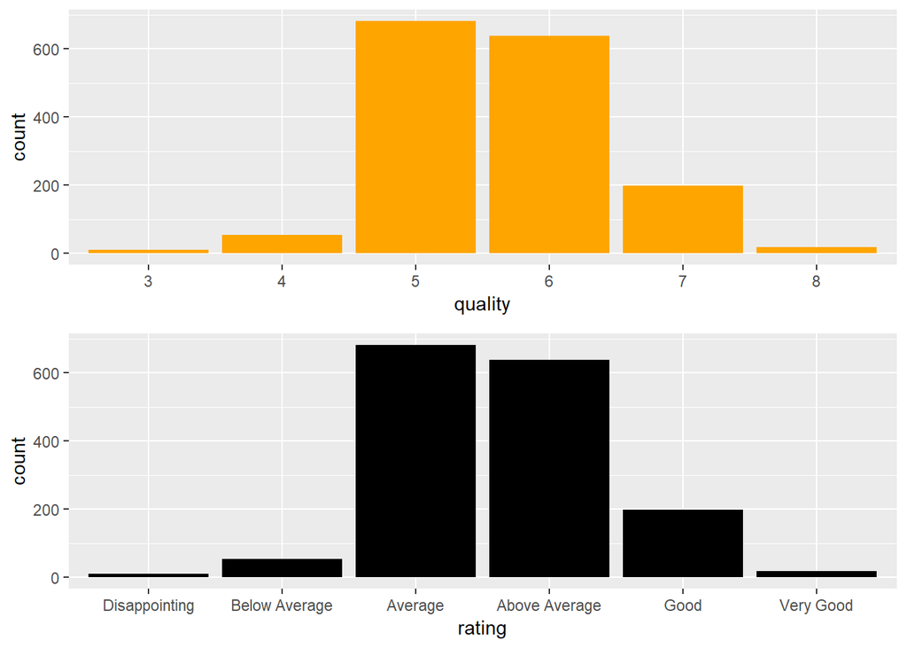

#### Obervations from the quality/rating bar charts:

- The data description states, quality is scored between 0 and 10. For analysis purposes, numeric rating values were converted to categories: 0 - Very Bad, 1 - Bad, 2 - Very Disappointing, 3 - Disappointing, 4 - Below Average, 5 - Average, 6 - Above Average, 7 - Good, 8 - Very Good, 9 - Excellent, and 10 - Very Excellent.
- Quality ratings for the red wine sample range from 3 to 8 (Disappointing to Very Good). The majority of red wine in this sample are rated between 5 and 6 (Average and Above Average) and sample doesn’t have red wine rated beteen 0 and 2 (Very Bad to Very Disappointing), or between 9 and 10 (Excellent to Very Excellent).

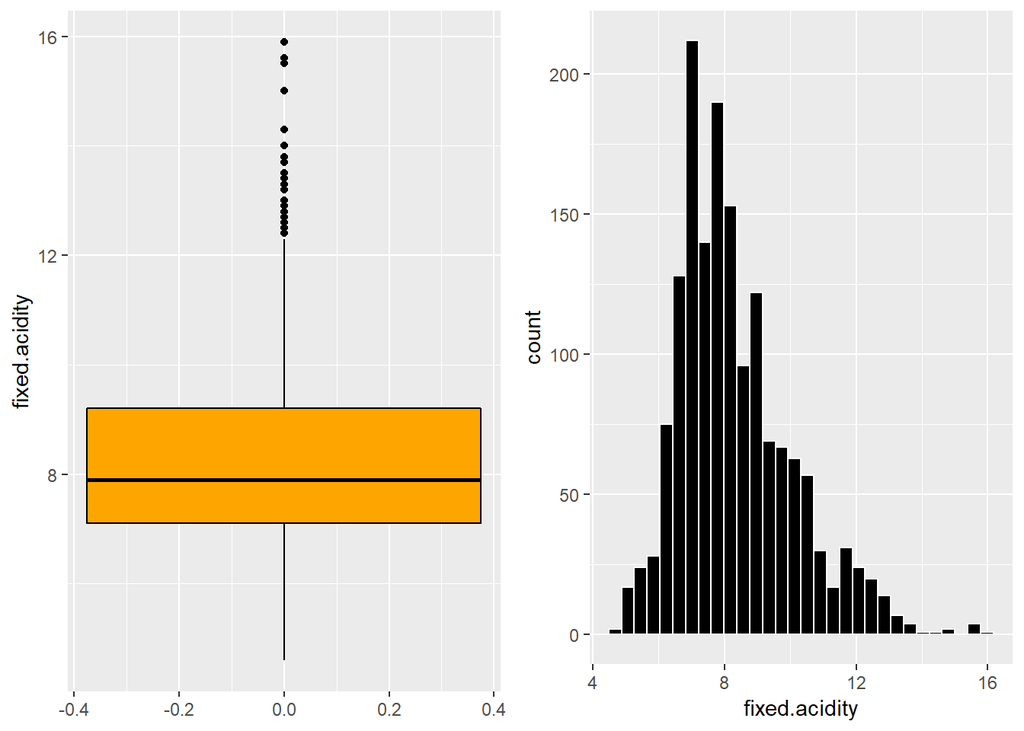

```
##    Min. 1st Qu.  Median    Mean 3rd Qu.    Max.
##    4.60    7.10    7.90    8.32    9.20   15.90
```

#### Observations from distribution, box plot and summary of fixed acidity:

- The data description states, fixed acidity is most the acids involved with wine, fixed or nonvolatile (do not evaporate readily).
- The distribution does have normal shape, although it is slightly skewed postive to the right due to some outliers and large values. The mean (8.32) is slighlty larger median (7.9) and the range of distribution is Max 15.90 - Min 4.60 = 11.

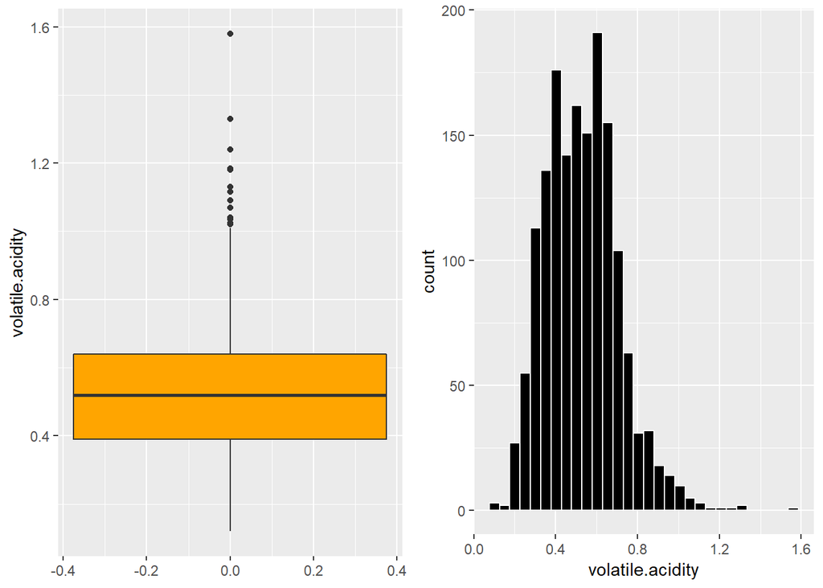

```
##    Min. 1st Qu.  Median    Mean 3rd Qu.    Max.
##  0.1200  0.3900  0.5200  0.5278  0.6400  1.5800
```

#### Observations from distribution, box plot and summary of volatile acidity:

- The data description states, volatile acidity is the amount of acetic acid in wine, which at too high of levels can lead to an unpleasant, vinegar taste.
- The distribution has normal shape; some outliers, but doesn’t affect the shape. The mean and median are the same at around (.52) and the range of distribution is Max 1.58 - Min .12 = 1.46.

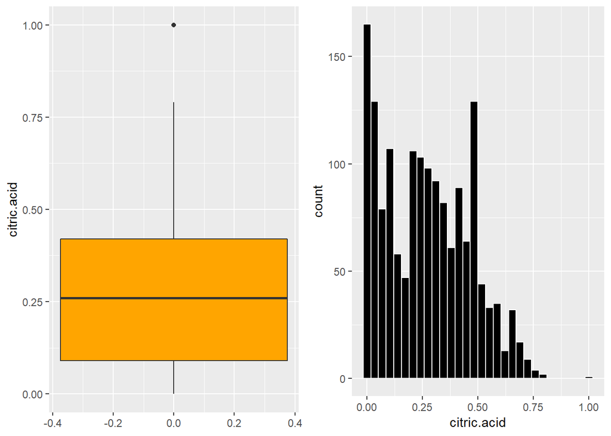

```
##    Min. 1st Qu.  Median    Mean 3rd Qu.    Max.
##   0.000   0.090   0.260   0.271   0.420   1.000
```

#### Observations from distribution, box plot and summary of citric acid:

- The data description states, found in small quantities, citric acid can add ‘freshness’ and flavor to wines.
- Citric acid variable has a positive skew to the right, but this isn’t due to outliers, there is only one.
- The the distribution can almost be described as multimodal; you can almost see three distinct right skewed distributions.
- Most the data in the distribution lie between 0 and .5 with 0 being the largest value and .5 as the second largest values being so far away are helping to spread the distribution out.
- The Range is Max 1 - Min 0 = 1, The median is .26 and mean slightly larger at .271 which shows in the distribution positively skewed to the right.

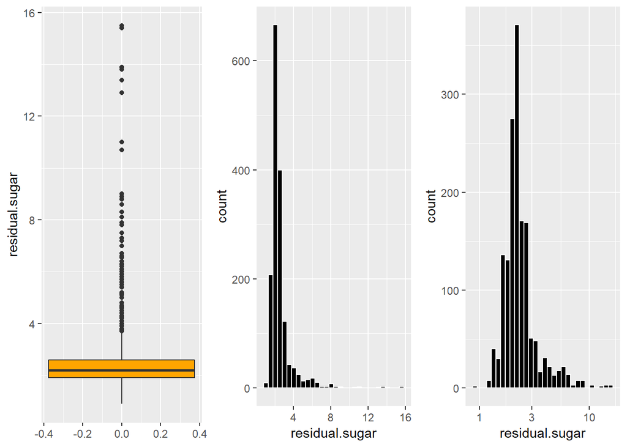

```
##    Min. 1st Qu.  Median    Mean 3rd Qu.    Max.
##   0.900   1.900   2.200   2.539   2.600  15.500
```

#### Observations from distribution, box plot and summary of residual sugar:

- The description states, residaul sugar is the amount of sugar remaining after fermentation stops, it’s rare to find wines with less than 1 gram/liter and wines with greater than 45 grams/liter are considered sweet.
- The data is concentrated between 1 and 4 with a median (2.2), mean (2.539), and Max (15.5) - Min (.90) = range (14.6).
- Due to many outliers and large values the distribution is long tailed; I plotted an additional histogram on a logarithmic scale, after the transformation the data has more normal distribution.

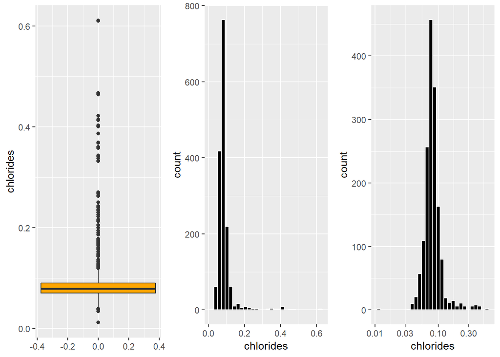

```
##    Min. 1st Qu.  Median    Mean 3rd Qu.    Max.
## 0.01200 0.07000 0.07900 0.08747 0.09000 0.61100
```

#### Observations from distribution, box plot and summary of chlorides:

- The description states, chlorides are the amount of salt in the wine.
- The data is concentrated between .02 and .12 with a median (.079), mean (.08747), and Max (.611) - Min (.012) = range (.599).
- Similar too residual sugar, due to many outliers and large values the distribution is long tailed; I plotted an additional histogram on a logarithmic scale, after the transformation the data has more normal distribution.

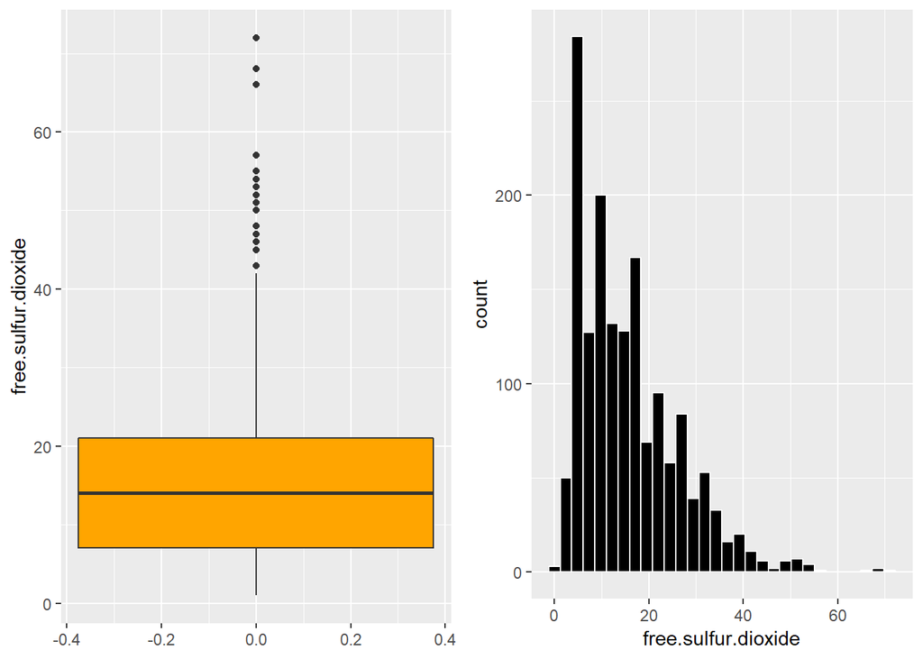

```
##    Min. 1st Qu.  Median    Mean 3rd Qu.    Max.
##    1.00    7.00   14.00   15.87   21.00   72.00
```

#### Observations from distribution, box plot and summary of free sulfur dioxide:

- The description states, free sulfur dioxide is the free form of SO2 exists in equilibrium between molecular SO2 (as a dissolved gas) and bisulfite ion; it prevents microbial growth and the oxidation of wine.
- The distribution suffers from very large outliers skewing the distribution positive to the right. The Max (72.00) - Min (1.00) = Range (71.00), please note the large range, and median (14.00) and mean (15.87). The data is concentrated between 5 and 30.

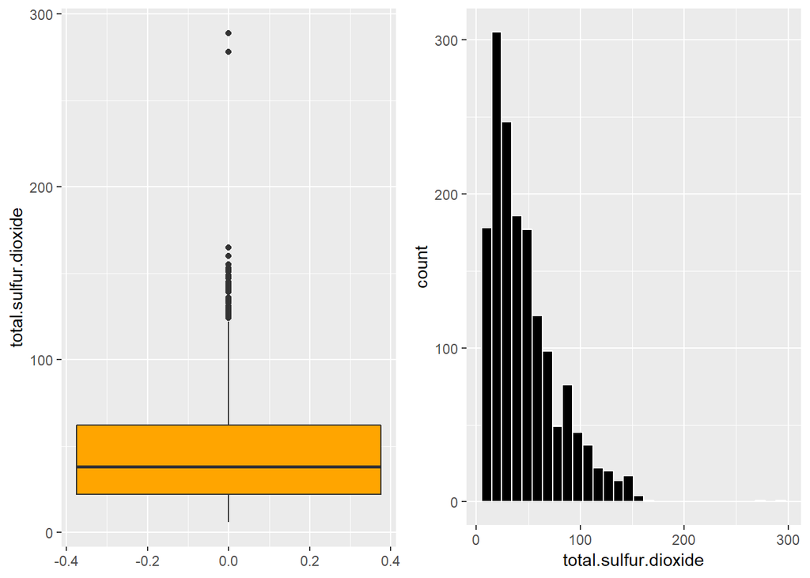

```
##    Min. 1st Qu.  Median    Mean 3rd Qu.    Max.
##    6.00   22.00   38.00   46.47   62.00  289.00
```

#### Observations from distribution, box plot and summary of total sulfur dioxide:

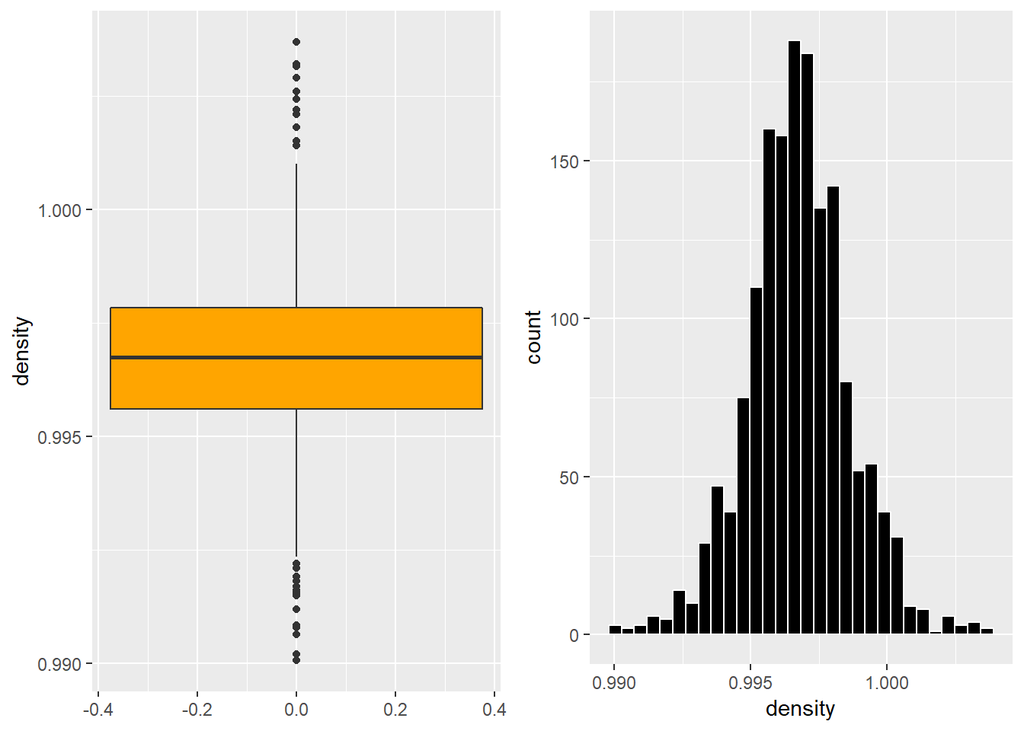

```
##    Min. 1st Qu.  Median    Mean 3rd Qu.    Max.
##  0.9901  0.9956  0.9968  0.9967  0.9978  1.0037
```

#### Observations from distribution, box plot and summary of density:

- The description states, density of wine is close to that of water depending on the percent alcohol, sugar content, acidity.
- The data is normally distributed; some outliers, but they’re evenly distributed across both tails. The mean and median are roughly the same (.99) and the range is small .0136.

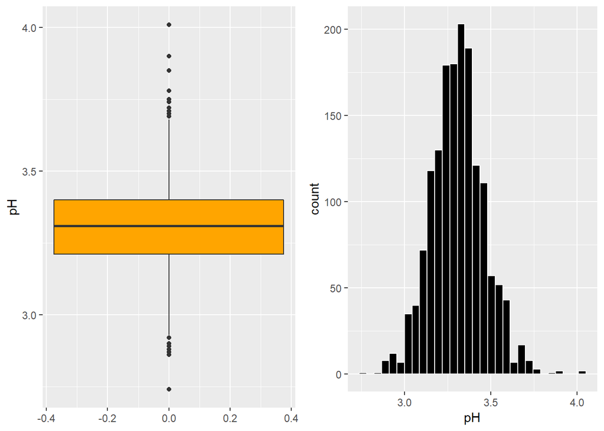

```
##    Min. 1st Qu.  Median    Mean 3rd Qu.    Max.
##   2.740   3.210   3.310   3.311   3.400   4.010
```

#### Observations from distribution, box plot and summary of pH:

- The description states, pH describes how acidic or basic a wine is on a scale from 0 (very acidic) to 14 (very basic); most wines are between 3-4 on the pH scale.
- The data is normally distributed; some outliers, but they’re evenly distributed across both tails. The mean and median are roughly the same (3.31) and the range is small 1.27.

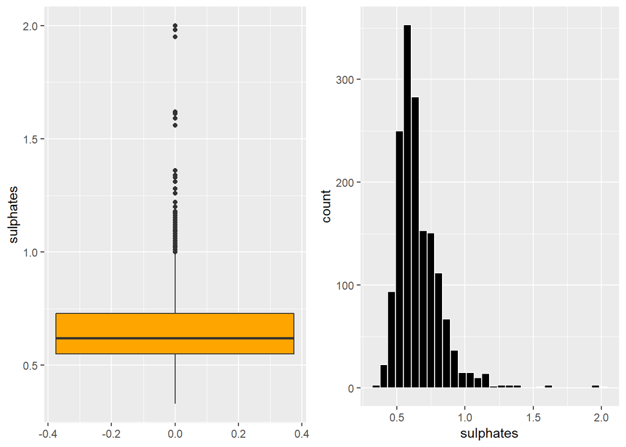

```
##    Min. 1st Qu.  Median    Mean 3rd Qu.    Max.
##  0.3300  0.5500  0.6200  0.6581  0.7300  2.0000
```

#### Observations from distribution, box plot and summary of sulphates:

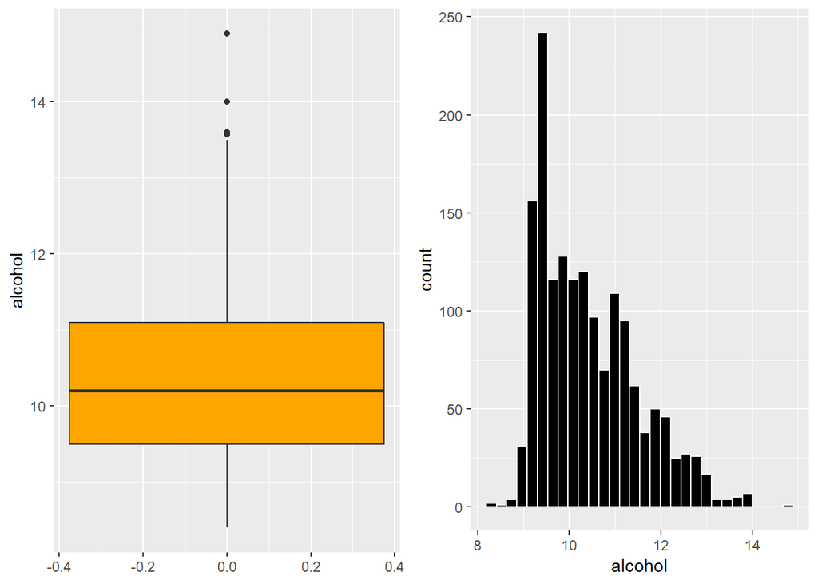

```
##    Min. 1st Qu.  Median    Mean 3rd Qu.    Max.
##    8.40    9.50   10.20   10.42   11.10   14.90
```

#### Observations from distribution, box plot and summary of alcohol:

- The description states, alcohol is the percent of alcohol content of the wine.
- Median of 10.20 and a mean 10.42; fairly close considering the data appears to have a positve right skew. Alcohol percentage ranges between 8.4 and 14.9 with the majority between 9 and 12.

# Univariate Analysis

### Structure of Dataset

- The dataset has 1,599 observations and 11 attributes that make up compostion of wine: fixed acidity, volatile acidity, citric acid, residual sugar, chlorides, free sulfur dioxide, total sulfur dioxide, density, ph, sulphates, and alcohol. 3 additional variables, quality which is the rating, x which is the index or each observation in the data frame, and a ordered factor variable used categorize the quality ratings.
- PH and density have normal distributions, while fixed acidity and volatile acidity have close to normal distributions.
- Residual sugar, chlorides, free sulfur dioxide, total sulfur dioxide, sulphates and alcohol have log normal distributions.
- Residual sugar and chlorides have the most outliers.
- Citric acid has a large number of zero values.

### Main feature of Interest

- The main feature of interest is quality and variables that affect the quality rating.

### Other Features or Interst

- Acidity, pH, and alcohol are important in wine making process and will likely support my investigation.

### New variables from Existing Variables

- Created a rating variable to categorize numeric quality ratings: 0 = Very Bad; 1 = Bad; 2 = Very Disappointing; 3 = Disappointing; 4 = Below Average; 5 = Average; 6 = Above Average; 7 = Good; 8 = Very Good; 9 = Excellent; 10 = Very Excellent.

### Unusual Distributions

- Residual Sugar and Chlorides variables, each had a large amount of outliers which caused the distribution to become right skewed. To interepret the data, a logarithmic transformation was applied. After, the transformation was applied the distributions appeared closer to a normal distribution.

# Bivariate Plots Section

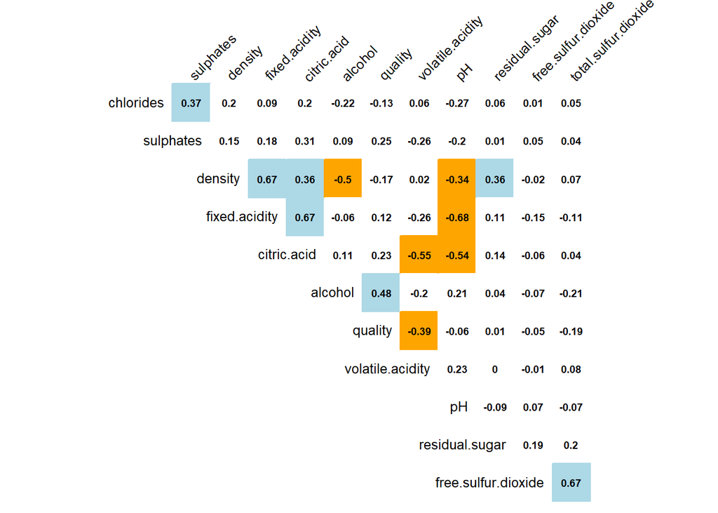

#### Observations from the Correlation matrix:

- The variables with strongest correlation to quality are alcohol (.48 moderate positive correlation) and volatile acidity (-.39 moderate negative correlation).
- PH has moderate negative correlation with fixed acidity and citric acid, except volatile acidity which has a weak positive correlation.
- Acidity variables all show a moderate correlation to one another. Also, free and total sulfur dioxide too.
- Density and alcohol have a moderate negative correlation.

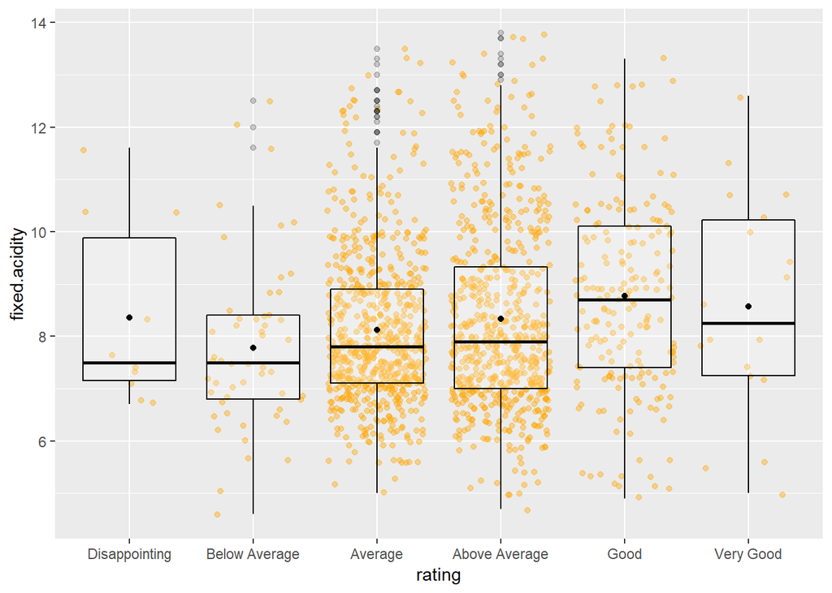

#### Observations from the box plot by quality rating compared to fixed acidity:

- The fixed acidity amount compared to the quality rating remains largely unchanged.
- The mean and median are similar across ratings.

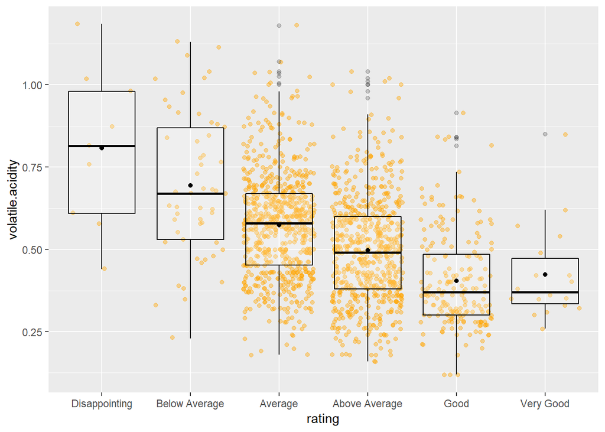

#### Observations from the box plot by quality rating compared to volatile acidity:

- As volatile acid increases the rating decreases; wines with high ratings have lower volatile acid.
- Looking at the plot you can can see the negative realtionship and average volatile acid decreasing as wine quality improves.

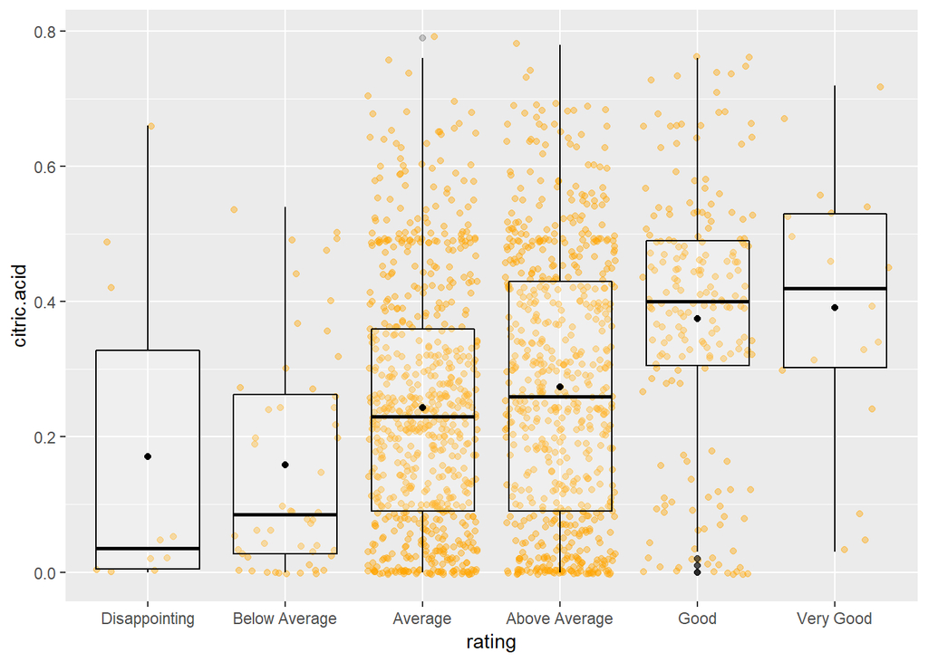

#### Observations from the box plot by quality rating compared to citric acid:

- As citric acid increases the rating increase; wines with high ratings have higher citric acid.
- Looking at the plot you can can see the postive realtionship and average citric acid increasing as wine quality improves.

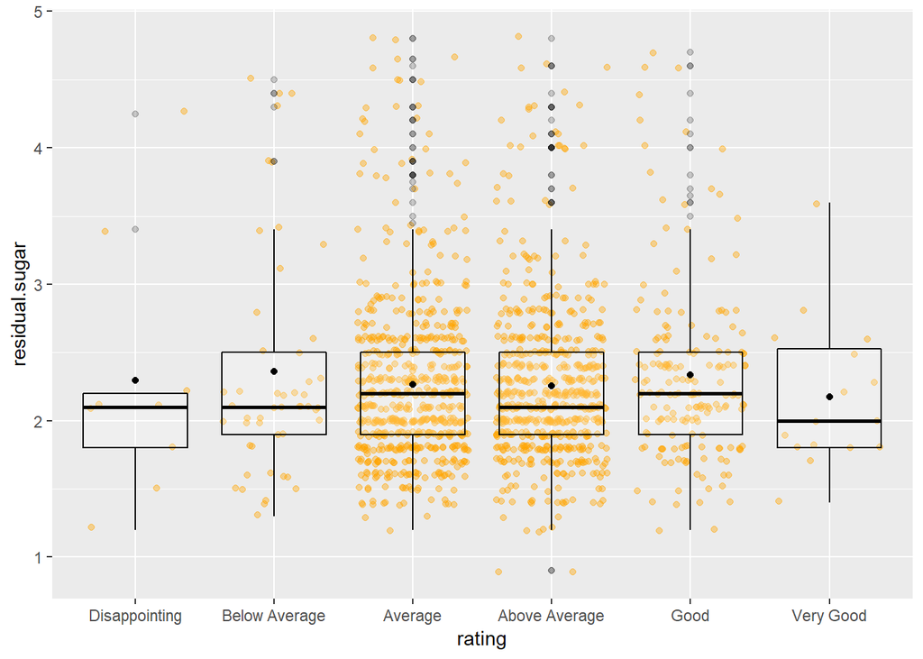

#### Observations from the box plot by quality rating compared to residual sugar:

- Residual sugar does not affect quality rating.
- The mean and median values for each quality rating are the same.

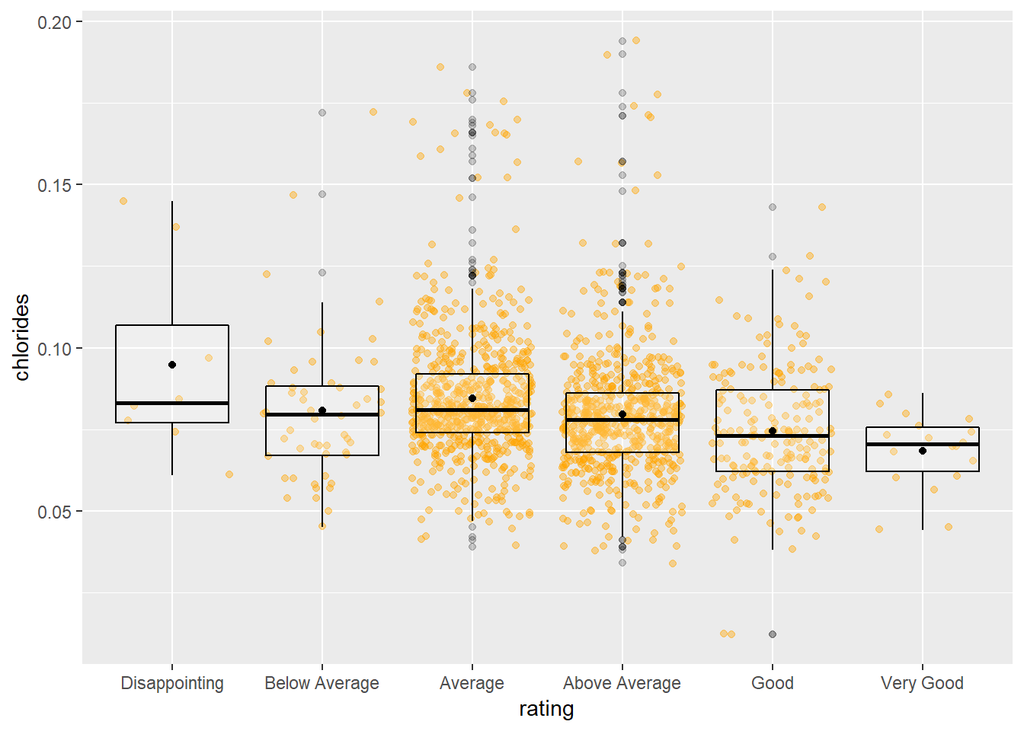

#### Observations from the box plot by quality rating compared to chlorides:

- Chlorides do not affect quality rating either, but better wines do tend to have less chlorides although the difference is very small.
- The mean and median values chlorides for each quality rating is similar, but again average chlorides are a slightlower for better wines.

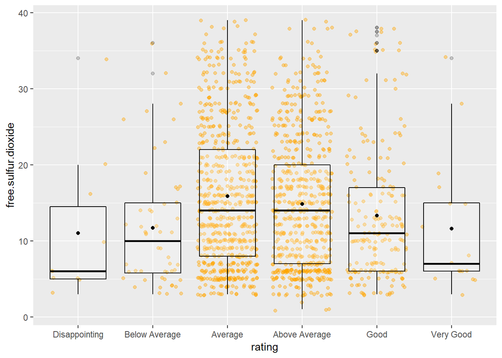

#### Observations from the box plot by quality rating compared to free sulfur dioxide:

- Wines rated below average and lower, have lower concentrations of free sulfur dioxide.
- Wines considered good or very good also have lower concentration of free sulfur dioxide.
- while average and above average rated wines have higher concentrations of free sulfur dioxide.

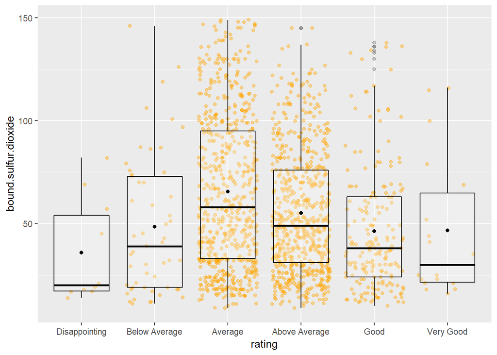

#### Observations from the box plot by quality rating compared to bound sulfur dioxide:

- Bound sulfur dioxide, or combined sulfur dioxide is the part of sulfur dioxide that combines with other wine materials and is chemically bound to the other materials and no longer in the free form.
- We see a similar trend in bound sulfer dioxide, wines rated below average and lower, have lower concentrations of bound sulfur dioxide.
- Wines considered good or very good also have lower concentration of bound sulfur dioxide.
- While average and above average rated wines have higher concentrations of bound sulfur dioxide.

### Relationships between the Forms of Sulfur Dioxide

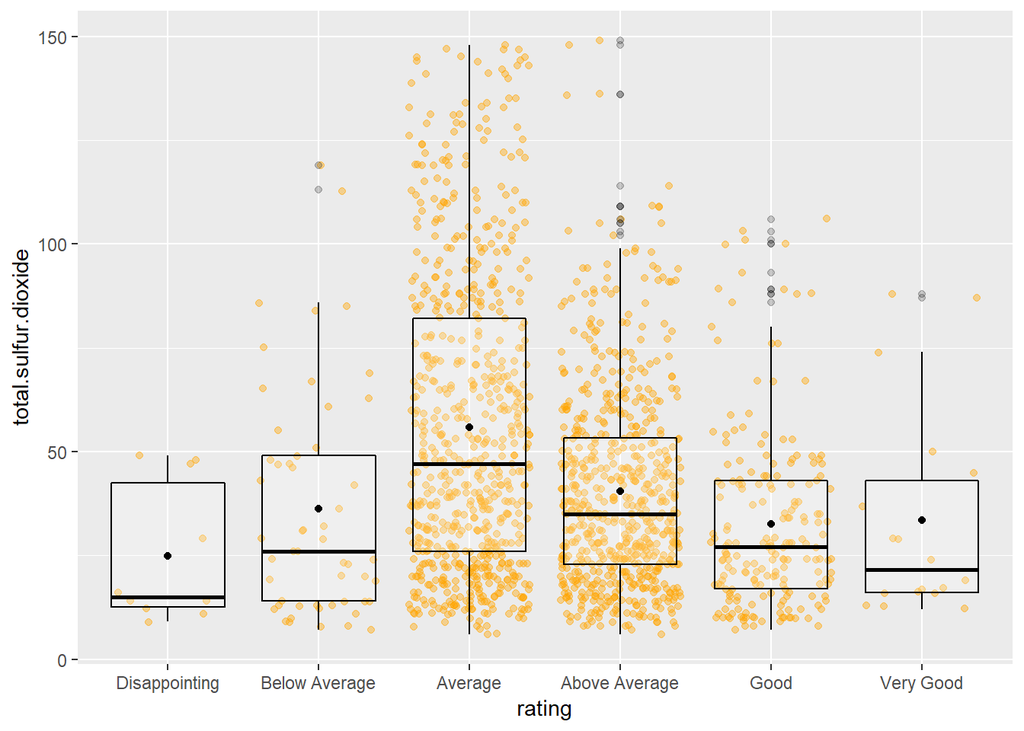

#### Observations from the box plot by quality rating compared to total sulfur dioxide:

- Total sulfur dioxide has similar trend to free and bound sulfur dioxide. Wines rated below average and lower, have lower concentrations of total sulfur dioxide.
- Wines considered good or very good also have lower concentration of total sulfur dioxide.
- while average and above average rated wines have higher concentrations of total sulfur dioxide.

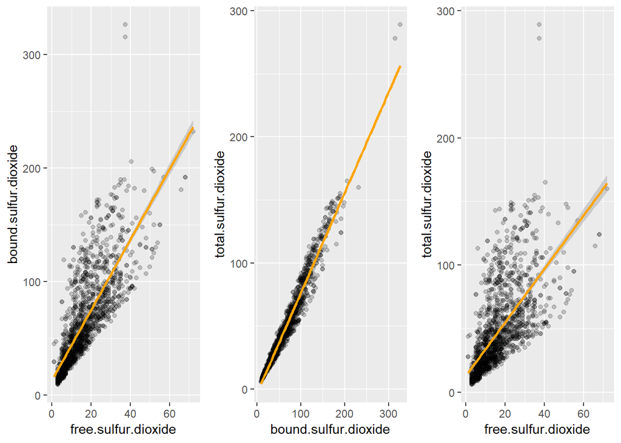

#### Observations from the scatter plots comparing the forms of sulfur dioxide:

- Sulfur dioxide amounts have a postive correlations between them. As one form of sulfur dioxide increases the other forms of sulfur dioxide increases.

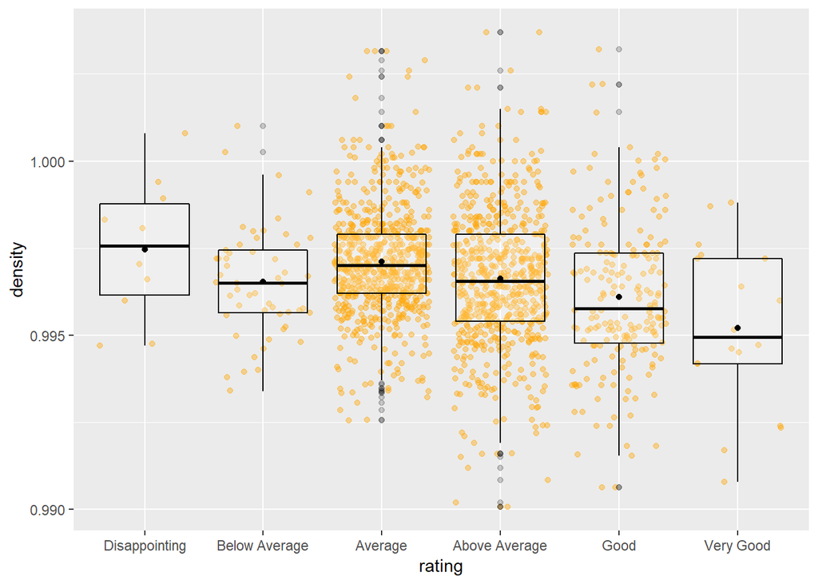

#### Observations from the box plot by quality rating compared to desity:

- Density seems to decrease as the rating increases; better wines have lower densities.
- Alcohol did have moderate negative correlation coefficient with density and it suspected that alcohol influences the quality of wine.

### Relationship between Density and Alcohol

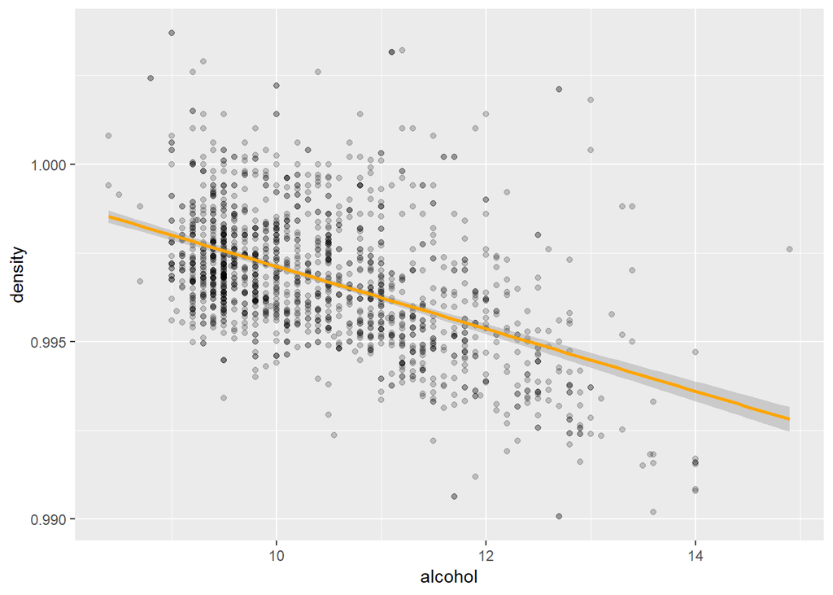

#### Observations from the scatter plot comparing density to alcohol:

- We can see from the scatter plot as alcohol percentage is increased the density of the wine is lower.
- Alcohol is less dense than water; a negative correlation makes sense.

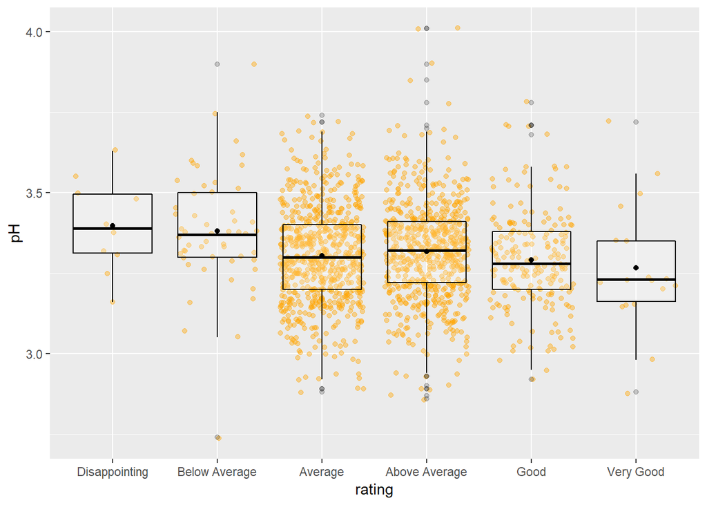

#### Observations from the box plot by quality rating compared to pH:

- Ph levels for wine are typically between 3 and 4; our sample is within that range for most part.
- It seems Ph levels are higher in lower quality wines than higher quality wines.
- Ph is the measure of strengh of total acids (fixed, volatile, and citric). The general guideline is lower ph; higher acidity. From this visual, better quality wines are more acidic on average.

### Relationship between PH and Acidity

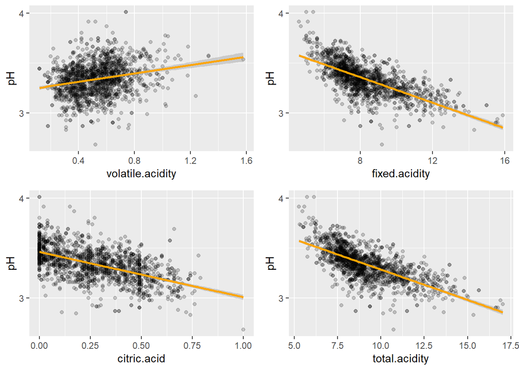

#### Further Observation on PH and Volatile Acidity

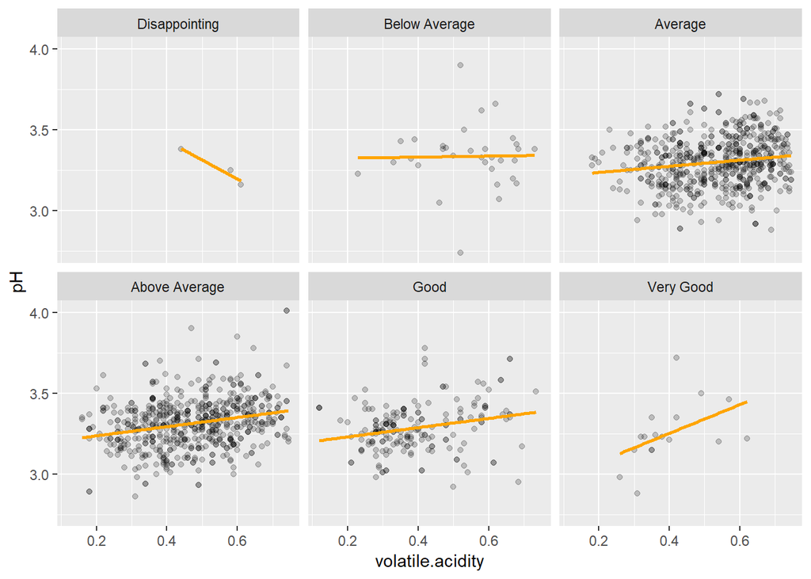

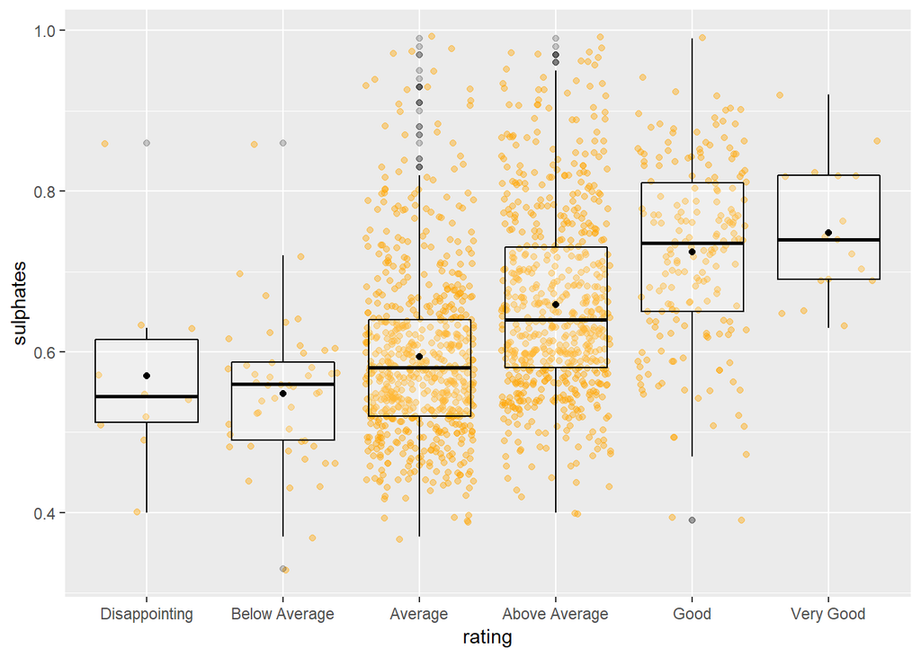

#### Observations from the box plot by quality rating compared to sulphates:

- Better quality wines have a stronger concentration of sulphates

### Relationship between Sulphates and Chlorides

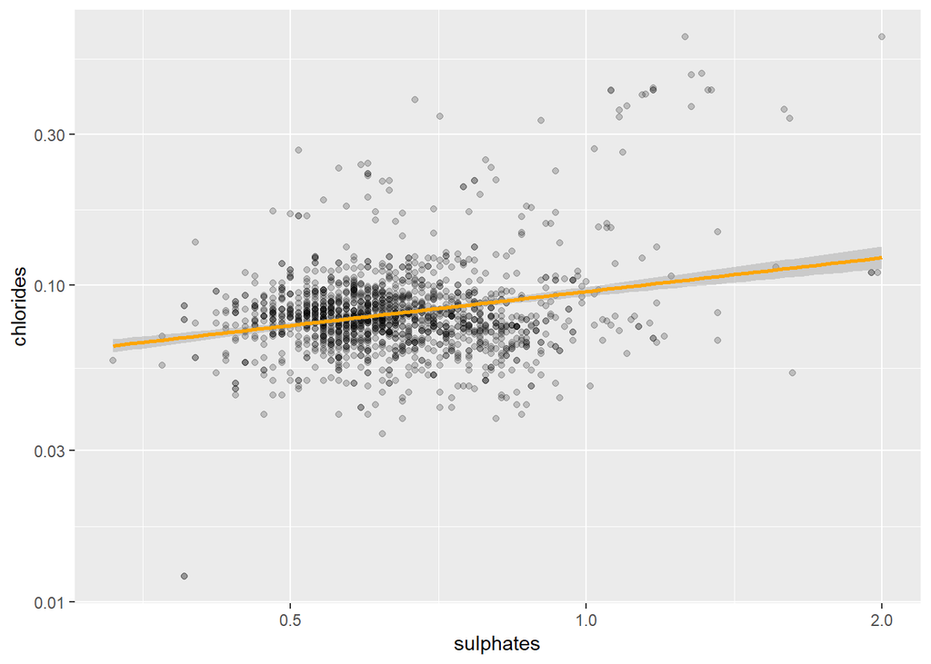

#### Observation from the scatter plots comparing sulpahtes and chlorides:

- Low moderate positive correlation between sulphates and chlorides.
- Sulphates levels increase on average as chlorides (saltiness) increases in . Seems odd, as chlorides increase wine quality decreases slightly and as sulphates increase wine quality increases.

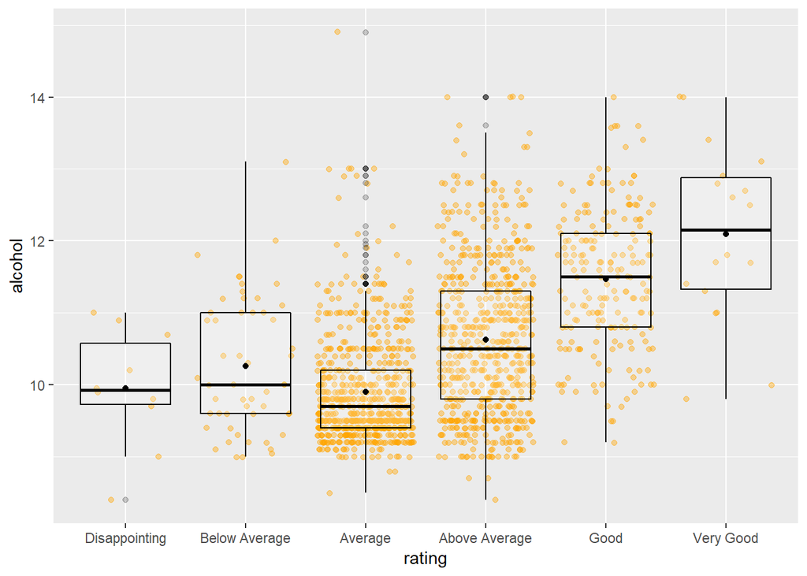

#### Observations from the box plot by quality rating compared to alcohol:

- Alcohol percentage and rating has moderate positive correlation.
- Out of all the variables alcohol is the strongest correlated with the quality rating. As the rating increases the alcohol percentage increases.

### Linear Model of Alcohols Relationship with Quality

```
##
## Call:
## lm(formula = quality ~ alcohol, data = rw)
##
## Residuals:
##     Min      1Q  Median      3Q     Max
## -2.8442 -0.4112 -0.1690  0.5166  2.5888
##
## Coefficients:
##             Estimate Std. Error t value Pr(>|t|)
## (Intercept) -0.12503    0.17471  -0.716    0.474
## alcohol      0.36084    0.01668  21.639   <2e-16 ***
## ---
## Signif. codes:  0 '***' 0.001 '**' 0.01 '*' 0.05 '.' 0.1 ' ' 1
##
## Residual standard error: 0.7104 on 1597 degrees of freedom
## Multiple R-squared:  0.2267, Adjusted R-squared:  0.2263
## F-statistic: 468.3 on 1 and 1597 DF,  p-value: < 2.2e-16
```

- Here’s a linear model between the variables quality and alcohol. Our t-value is 21.639, which is far from 0, which indicate a relationship exists between quality and alcohol. F value is 468.3 very far from 1; again, indicates a relationship. Our R-squared value is only 22.6%, so we must have other variables that are affecting the quality raing.

```
##      fixed.acidity volatile.acidity citric.acid residual.sugar chlorides
## [1,]          0.12            -0.39        0.23           0.01     -0.13
##      free.sulfur.dioxide total.sulfur.dioxide density    pH sulphates
## [1,]               -0.05                -0.19   -0.17 -0.06      0.25
##      alcohol
## [1,]    0.48
```

#### The variables that are most correlated to quality:

- Alcohol
- Volatile Acidity
- Sulphates
- Citric Acid

We’ll examine these further in the multivariate section and others that indirectly affect quality.

# Bivariate Analysis

## Relationships Observed with Quality

- Wine quality has the strongest correlation with alcohol (.48), volatile acidity (-.39), sulphates (.25), and citric acid (.23).
- Better wines has higher alcohol percentages, lower volatile acidity, higher sulphates, and higher citric acid.
- the other variables had very weak correlations to quality.
- Better wines are more acidic.
- variables with the strongest correlation to quality; they range from moderate to weak.
- Alcohol makes up 22.6% of the variance in quality.

### Strongest relationships

#### To our Main Feature Quality:

- Alcohol .48
- Volatile Acidity -.39
- ph seems to play a indirect role to quality as it affects both alcohol and acidity

#### Other variables :

- fixed acid - pH -.68
- free Sulfure Dioxide - total Sulfur Dioxide .67
- fixed acid - density .67
- fixed acid - citric acid .67

# Multivariate Plots Section

In our bivariate exploration; alcohol and acidity seem to have the most affect on quality ratings; also, sulphates seem to support this too. Let’s explore these variables further along with a few others that may indirectly affect a wines quality rating.

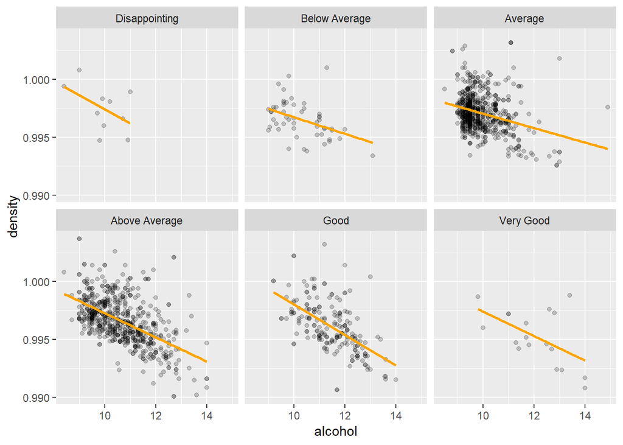